# Skrypty geoprzetwarzania

Dostęp do danych satelitarnych

Author

Krzysztof Dyba

```r
library("terra")
```

# Wprowadzenie

## Dane satelitarne

Dane satelitarne odgrywają kluczową rolę w systemach informacji geograficznej i wykorzystywane są w szerokim zakresie do kartowania, analizy pokrycia terenu, monitorowania zmian w środowisku, zarządzania kryzysowego czy rolnictwa precyzyjnego. Źródłem danych mogą być:

- sensory optyczne (pozyskują dane w różnych spektrach fali elektromagnetycznej, np. światło widzialne, bliska podczerwień, podczerwień krótkofalowa czy podczerwień termalna).
- sensory radarowe (emitują impulsy radarowe, a następnie mierzą odbitą energię. W przeciwieństwie do sensorów optycznych mogą być wykorzystywane do obrazowania powierzchni przez chmury oraz w nocy).

W kontekście ogromnych zbiorów danych satelitarnych nie sposób pominąć zasadniczych technologii ułatwiających ich przetwarzanie:

- **S**patio**T**emporal **A**sset **C**atalogs – ustandaryzowany sposób organizowania i opisywania zbiorów danych przestrzennych ułatwiający ich wyszukiwanie oraz dostęp (https://stacspec.org).
- *Byte serving* (*range requests*) – technika używana w protokole HTTP do przesyłania tylko określonej części pliku z serwera do klienta. Jest to szczególnie przydatne w przypadku dużych plików, gdzie pobieranie całego pliku może być nieefektywne lub niepotrzebne. Ta technika umożliwia wydajny dostęp do wymaganych zakresów danych bez przesyłania niepotrzebnych części.
  - **C**loud **O**ptimized **G**eotiff – specjalny format przechowywania danych geoprzestrzennych (takich jak zdjęcia satelitarne) zaprojektowany z myślą o środowiskach chmurowych. Opiera się na standardowym formacie Geotiff, ale jest optymalizowany pod kątem wydajnego dostępu i przetwarzania w chmurze. Oprócz *byte serving*, stosowane są podglądy (*overviews*), czyli warstwy rastra w niższej rozdzielczości, umożliwiając jego renderowanie bez konieczności dostępu do danych w pełnej rozdzielczości (https://www.cogeo.org/).
  - **V**irtual **F**ile **S**ystems – umożliwia jednolity dostęp do różnych typów przechowywania danych (https://gdal.org/user/virtual_file_systems.html). Jednym z modułów jest `vsicurl`, który zapewnia bezpośredni dostęp do zdalnych plików przez protokoły HTTP(S) i FTP bez konieczności pełnego pobierania, tym samym minimalizując transfer danych.

## Przetwarzanie potokowe

Przetwarzanie potokowe w kontekście analizy danych odnosi się organizacji przepływu pracy w sposób liniowy (sekwencyjny). Oznacza to, że dane przepływają przez serię etapów (funkcji), w których wynik jednego etapu służy jako wejście do kolejnego. W praktyce sprawia to, że kod jest bardziej przejrzysty i łatwiejszy do zrozumienia.

W **R** wbudowanym operatorem przypływu jest `|>`. Do jego zapisu można wykorzystać skrót klawiszowy `CTRL + SHIFT + M`, jednak wymaga to zaznaczenia opcji `Use native pipe operator` (zakłada `Code > Editing`) w **RStudio**.

Przykładowo, możemy wylosować 10 liczb z rozkładu normalnego, następnie obliczyć wartość bezwzględną, posortować w kolejności rosnącej i finalnie nadpisać obiekt `dane`.

```r
dane = rnorm(10)
dane |>
  abs() |>
  sort() -> dane
dane
```

```
 [1] 0.5523812 0.6034717 0.6419994 0.6540564 0.7189717 0.7886544 1.1437211
 [8] 1.3426453 1.7735580 2.1543514
```

# Pozyskiwanie danych

Do obsługi katalogów STAC w **R** służy pakiet **rstac**, który umożliwia wyszukiwanie i pobieranie danych zgodnie z tym standardem.

```r
library("rstac")
```

W pierwszym kroku należy zdefiniować źródło danych używając funkcji `stac()`. Wykaz źródeł można znaleźć na [STAC Index](https://stacindex.org/). W naszym przykładzie wykorzystamy usługę [Earth Search](https://element84.com/earth-search/), która dostarcza m. in. zdjęcia satelitarne z Landsata oraz Sentinela.

```r
stac_source = stac("https://earth-search.aws.element84.com/v1")
stac_source
```

```
###rstac_query
- url: https://earth-search.aws.element84.com/v1/
- params:
- field(s): version, base_url, endpoint, params, verb, encode
```

W wyniku tej operacji otrzymaliśmy obiekt `rstac_query`, który zawiera informacje o zapytaniu HTTP, które zostanie wysłane do serwera. Możemy wyróżnić dwie metody wysyłania żądań:

- GET (`get_request()`) – służy głównie do pobierania danych z serwera. Dane przesyłane są poprzez adres URL jako parametry zapytania.
- POST (`post_request()`) – służy głównie do przesyłania danych na serwer. Dane są wysyłane w treści (*body*) żądania HTTP.

Wybór metody zależy od serwera.

Spróbujmy teraz odpytać serwer jakie zbiory danych znajdują się na nim.

```r
kolekcje = stac_source |>
  collections() |>
  get_request()
kolekcje
```

```
###Collections
- collections (9 item(s)):
  - sentinel-2-pre-c1-l2a
  - cop-dem-glo-30
  - naip
  - cop-dem-glo-90
  - landsat-c2-l2
  - sentinel-2-l2a
  - sentinel-2-l1c
  - sentinel-2-c1-l2a
  - sentinel-1-grd
- field(s): collections, links, context
```

W odpowiedzi otrzymaliśmy obiekt, który jest wielopoziomową listą list. Można samodzielnie sprawdzić jego strukturę używając funkcji `View()`. Eksploracja takich obiektów jest bardziej skomplikowana w porównaniu do obiektów jednowymiarowych (np. wektorów). Przykładowo, jeżeli chcemy sprawdzić pozostałe dostępne zbiory danych, to należy wykorzystać funkcje `lapply()`, która wykonuje iterację po każdym elemencie danych wejściowych (w tym przypadku listy), stosując przy tym podaną funkcję. Jako wynika zwracana jest lista, którą następnie można uprościć do wektora używając funkcji `unlist()`.

Dodatkowo, dla uproszczenia możemy zastosować funkcję lambda (inaczej funkcję anonimową). Pozwala to zamienić słowo kluczowe `function()` na znak `\()`, np. zamiast `lapply(lista, function(x) x^2)` będzie `lapply(lista, \(x) x^2)`.

```r
kolekcje_nazwy = unlist(lapply(kolekcje$collections, \(x) x$id))
kolekcje_nazwy
```

```
[1] "sentinel-2-pre-c1-l2a" "cop-dem-glo-30"        "naip"
[4] "cop-dem-glo-90"        "landsat-c2-l2"         "sentinel-2-l2a"
[7] "sentinel-2-l1c"        "sentinel-2-c1-l2a"     "sentinel-1-grd"
```

Uwaga! Dane z Sentinela-2 znajdują się w dwóch kolekcjach, tj. `sentinel-2-l2a` (starsza) i `sentinel-2-c1-l2a` (nowsza). Aktualnie trwa aktualizacja produktów do nowszej kolekcji `sentinel-2-c1-l2a` i ta powinna być preferowana, natomiast starsza kolekcja w przyszłości nie będzie obsługiwana.

Teraz wyszukajmy dostępne produkty w ramach kolekcji `sentinel-2-c1-l2a`. Do wyszukiwania danych służy funkcja `stac_search()` i umożliwia ona zdefiniowanie takich parametrów jak:

- kolekcja (`collections`),
- zakres przestrzenny w układzie WGS 84 (`bbox`),
- interwał czasowy w standardzie [RFC 3339](https://www.rfc-editor.org/rfc/rfc3339) (`datetime`),
- maksymalna liczba produktów (`limit`).

W tym przypadku żądanie musimy wysłać za pomocą metody POST.

```r
stac_source |>
  stac_search(
    collections = "sentinel-2-c1-l2a",
    bbox = c(22.5, 51.1, 22.6, 51.2), # xmin, ymin, xmax, ymax (WGS84)
    datetime = "2023-01-01T00:00:00Z/2023-12-31T00:00:00Z", # RFC 3339
    limit = 5) |>
  post_request() -> obrazy
obrazy
```

```
###Items
- matched feature(s): 288
- features (5 item(s) / 283 not fetched):
  - S2A_T34UEB_20231230T094411_L2A
  - S2A_T34UFB_20231230T094411_L2A
  - S2A_T34UEB_20231227T093411_L2A
  - S2A_T34UFB_20231227T093411_L2A
  - S2B_T34UEB_20231225T094326_L2A
- assets:
aot, blue, cloud, coastal, granule_metadata, green, nir, nir08, nir09, preview, product_metadata, red, rededge1, rededge2, rededge3, scl, snow, swir16, swir22, thumbnail, tileinfo_metadata, visual, wvp
- item's fields:
assets, bbox, collection, geometry, id, links, properties, stac_extensions, stac_version, type
```

Zostało znalezionych 288 produktów, które spełniają zadane warunki. Możemy zobaczyć jakie warstwy (*assets*) i atrybuty (*fields*) są powiązane. Sprawdźmy przykładowe cechy produktu (*properties*).

```r
# pierwsze 15 cech
names(obrazy$features[[1]]$properties)[1:15]
```

```
 [1] "created"              "platform"             "constellation"
 [4] "instruments"          "eo:cloud_cover"       "proj:epsg"
 [7] "proj:centroid"        "mgrs:utm_zone"        "mgrs:latitude_band"
[10] "mgrs:grid_square"     "grid:code"            "view:azimuth"
[13] "view:incidence_angle" "view:sun_azimuth"     "view:sun_elevation"
```

Mamy dostęp do 44 cech, które opisują produkt, m. in. data pozyskania, nazwa platformy satelitarnej, procentowe zachmurzenie sceny, układ współrzędnych, ID sceny, itd.

Sprawdźmy zachmurzenie wyszukanych scen. Określone jest one w atrybucie `eo:cloud_cover`. W tym celu ponownie musimy wykorzystać funkcję `lapply()`.

```r
unlist(lapply(obrazy$features, \(x) x$properties$"eo:cloud_cover"))
```

```
[1] 71.93396 68.93441 83.81743 94.01084 99.99993
```

Wyszukane sceny charakteryzują się wysokim zachmurzeniem w związku z czym ich przydatność jest ograniczona. Oczywiście możemy dokonać prostej filtracji modyfikując nasze poprzednie zapytanie. Do filtrowania przeznaczona jest funkcja `ext_query()`.

```r
stac_source |>
  stac_search(
    collections = "sentinel-2-c1-l2a",
    bbox = c(22.5, 51.1, 22.6, 51.2),
    datetime = "2023-01-01T00:00:00Z/2023-12-31T00:00:00Z",
    limit = 5) |>
  ext_query(`eo:cloud_cover` < 10) |>
  post_request() -> obrazy

unlist(lapply(obrazy$features, \(x) x$properties$"eo:cloud_cover"))
```

```
[1] 0.067071 0.043523 1.478151 0.678711 0.000757
```

Alternatywnie, zamiast używać wielopoziomowych list, możemy dokonać konwersji obiektu `obrazy` do “przestrzennej ramki danych” (*simple features data frame*) za pomocą funkcji `items_as_sf()`. Jednakże, na ten moment jest ona eksperymentalna i mogą pojawić się niespodziewane problemy.

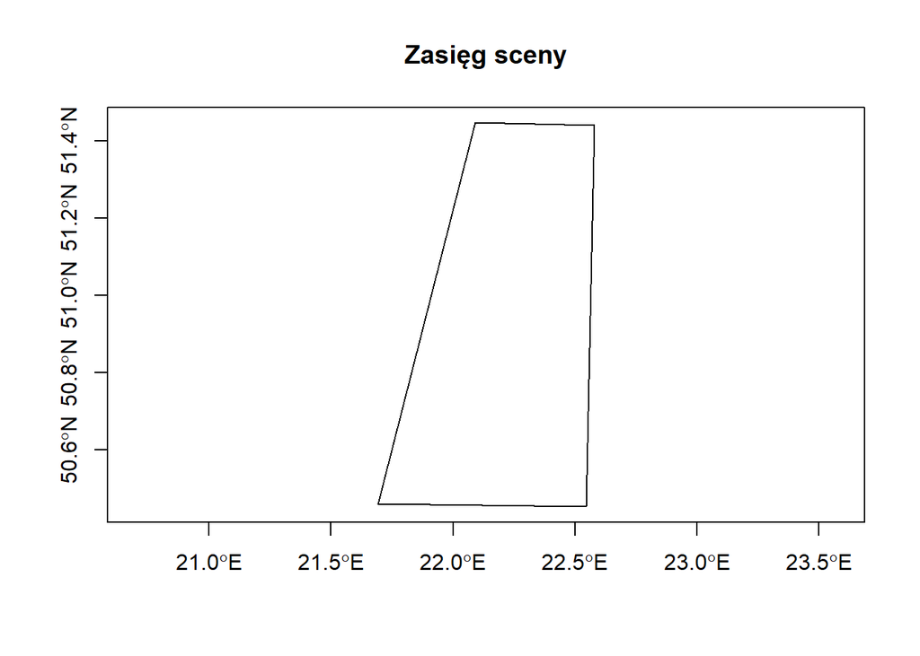

```r
df = items_as_sf(obrazy)
plot(sf::st_geometry(df)[1], main = "Zasięg sceny", axes = TRUE)
```

Po dokonaniu selekcji scen, możemy przystąpić do ich pobrania. Zasadniczo, można to wykonać na kilka różnych sposobów używając:

- funkcji `assets_download()` z pakietu **rstac**,
- funkcji `download.file()` wbudowanej w **R**,
- modułu `/vsicurl/` dostępnego w pakietach obsługujących GDAL, np. **terra**,
- narzędzi GDAL (np. [gdalwarp](https://gdal.org/programs/gdalwarp.html)) dostępnych m. in. w powłoce [OSGeo4W](https://www.osgeo.org/projects/osgeo4w/) na Windows.

## assets_download()

W funkcji `assets_download()` możemy zdefiniować, które warstwy chcemy pobrać (argument `asset_names`). Jednak ma ona pewien mankament związany z dość skomplikowanym zapisem ścieżek do pobranych plików wynikający ze struktury katalogów STAC.

```r
obrazy |>
  items_select(1) |>
  assets_download(asset_names = c("blue", "green", "red"))
```

Sceny satelitarne zazwyczaj zawierają niskorozdzielcze miniaturki w kompozycji RGB. W przypadku danych z Sentinela-2 zapisane są one jako `thumbnail.jpg`. Jeśli chcemy szybko podejrzeć dane, to możemy odwołać się do tej warstwy i pozyskać do niej odnośnik przy pomocy funkcji `assets_url()`. Do wczytania pliku .jpg wymagany jest dodatkowy pakiet, np. **imager**, który posiada funkcję `load.image()`.

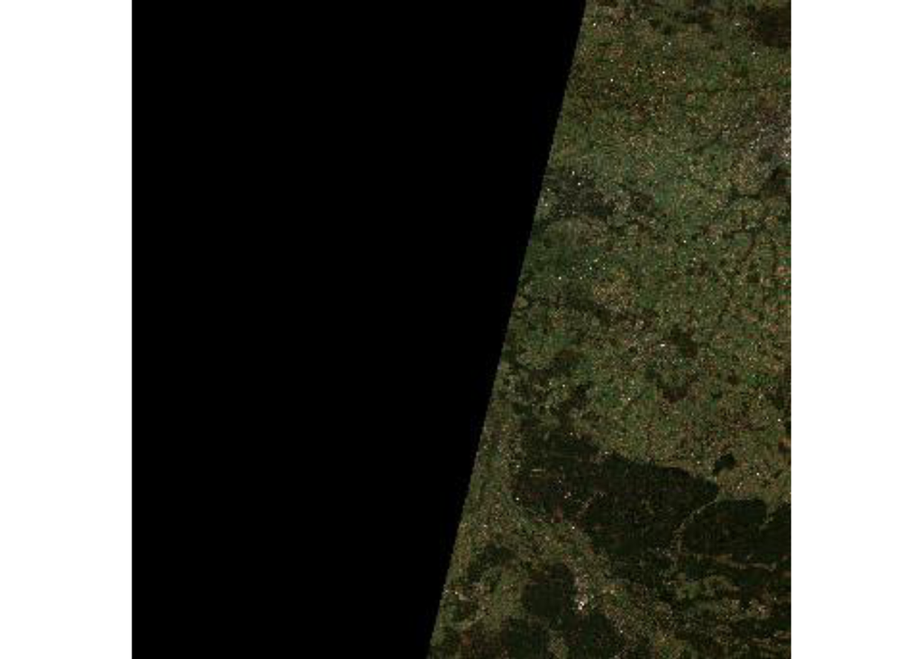

```r
library("imager")
par(mar = c(0, 0, 0, 0)) # usuń marginesy

obrazy |>
  items_select(1) |>
  assets_select(asset_names = "thumbnail") |>
  assets_url() |>
  load.image() |>
  plot(axes = FALSE)
```

## download.file()

Tak jak w powyższym przypadku, możliwe jest pozyskanie odnośników do pozostałych warstw i pobranie danych przy użyciu funkcji `download.file()`, wymagającej wskazania odnośników, z których zostaną pobrane dane oraz ścieżek zapisu.

```r
obrazy |>
   items_select(1) |>
   assets_select(asset_names = c("blue", "green", "red")) |>
   assets_url() -> urls
urls
```

```
[1] "https://e84-earth-search-sentinel-data.s3.us-west-2.amazonaws.com/sentinel-2-c1-l2a/34/U/EB/2023/11/S2A_T34UEB_20231107T093339_L2A/B02.tif"
[2] "https://e84-earth-search-sentinel-data.s3.us-west-2.amazonaws.com/sentinel-2-c1-l2a/34/U/EB/2023/11/S2A_T34UEB_20231107T093339_L2A/B03.tif"
[3] "https://e84-earth-search-sentinel-data.s3.us-west-2.amazonaws.com/sentinel-2-c1-l2a/34/U/EB/2023/11/S2A_T34UEB_20231107T093339_L2A/B04.tif"
```

Utwórzmy nowy folder o nazwie `sentinel` używając funkcji `dir.create()`. Do stworzenia ścieżek zapisu należy podać nazwę pliku wraz z rozszerzeniem. W tym celu można zastosować funkcję `basename()` do wyodrębnienia tych nazw z odnośników. Następnie należy połączyć ścieżkę do katalogu ze ścieżką do pliku wykorzystując funkcję `file.path()`.

```r
dir.create("sentinel")
rastry = file.path("sentinel", basename(sentinel))
```

Finalnie, zastosujemy pętlę, która pobierze wszystkie pliki do lokalizacji określonej przez nas.

```r
for (i in seq_along(sentinel)) {
  download.file(sentinel[i], rastry[i], mode = "wb")
}
```

## /vsicurl/

Ostatnim sposobem jest wykorzystanie modułu `/vsicurl/` pochodzącego z GDAL bez potrzeby pobierania całego zbioru danych. Działanie jest proste – wystarczy dodać przedrostek `/vsicurl/` do odnośników z rastrami używając funkcji `paste0()`.

```r
urls = paste0("/vsicurl/", urls)
r = rast(urls)
r
```

```
class       : SpatRaster
dimensions  : 10980, 10980, 3  (nrow, ncol, nlyr)
resolution  : 10, 10  (x, y)
extent      : 499980, 609780, 5590200, 5700000  (xmin, xmax, ymin, ymax)
coord. ref. : WGS 84 / UTM zone 34N (EPSG:32634)
sources     : B02.tif
              B03.tif
              B04.tif
names       :   B02,   B03,   B04
min values  :     1,     1,   473
max values  : 18640, 17728, 17104
```

Na końcu możemy przygotować kompozycję w świetle widzialnym używając funkcji `plotRGB()`.

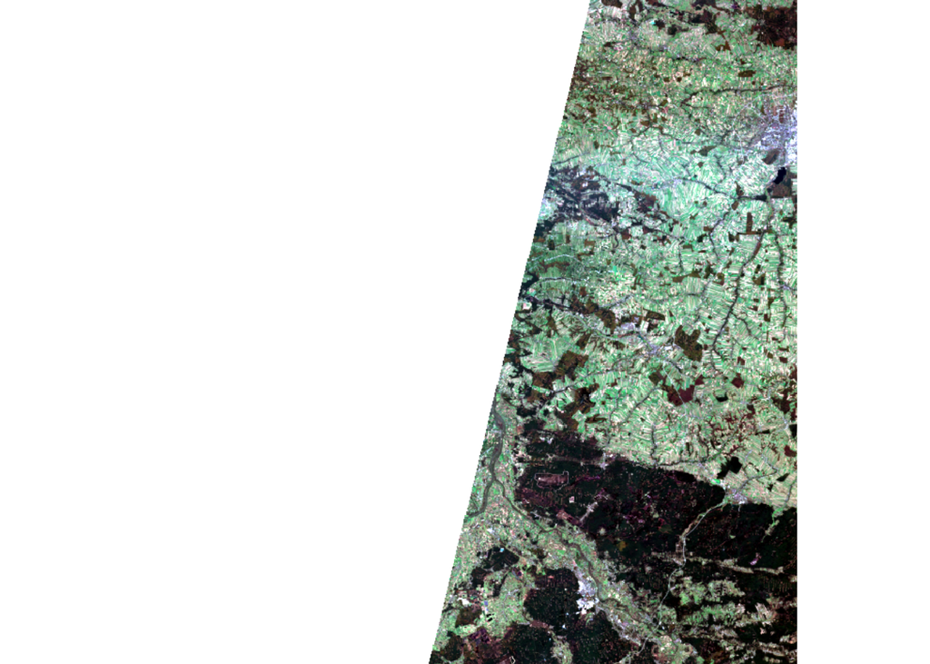

```r
plotRGB(r, r = 3, g = 2, b = 1, stretch = "lin")
```

Więcej informacji na temat wyszukiwania i pozyskiwania danych za pomocą standardu STAC znajdziesz w oficjalnym tutorialu [**Download data from a STAC API using R, rstac, and GDAL**](https://stacspec.org/en/tutorials/1-download-data-using-r/) napisanym przez Michael Mahoney.

# Zadanie

**6.** Pobierz dowolną scenę satelitarną z Sentinela-2 o niskim zachmurzeniu (maksymalnie 20%) i następnie:

- sprawdź metadane rastrów,
- przygotuj wizualizację w naturalnych barwach,
- pobierz losową próbę 10 tys. punktów dla kanału niebieskiego, zielonego, czerwonego oraz bliskiej podczerwieni i zaprezentuj statystyki opisowe (ustaw ziarno losowości oraz zwróć uwagę na brakujące wartości `NA`),
- zestaw cztery histogramy na jednym panelu,
- wykonaj wykres rozrzutu dla kanału czerwonego oraz bliskiej podczerwieni z zaznaczoną linią `x = y` i ustawioną przezroczystością punktów, następnie oblicz współczynnik korelacji Pearsona,
- oblicz znormalizowany różnicowy wskaźnik wegetacji ([NDVI](https://gisgeography.com/ndvi-normalized-difference-vegetation-index/)) i zaprezentuj go na mapie.